# Activity 10 - Practicing With Intervals for a Single Value

STS 2300

Updated: 2025-11-02

```r
library(ggplot2)
library(infer)
library(dplyr)
```

**To have this activity marked as “Complete”**: You need to complete **either** Part 1 (interval for proportion) or Part 2 (interval for mean). I encourage you to attempt both (you will be responsible for both on homework), both only one is required for this activity.

# Part 1 - Dog identifying COVID-19 samples correctly

For this activity, we’ll look at a study where researchers trained a dog to smell COVID-19 virus. If you’re interested, you can read more about it (and watch a video) [here](https://nerdist.com/article/dogs-sniff-out-covid/).

1. I’ve created a data frame using the data mentioned in the article. For now, we will just focus on how well the dog was able to identify cases that were positive for COVID-19. We will compare this to cases that were negative for COVID-19 in Activity 11. Use the code below to read the data into R. Then calculate the sample proportion that the dog correctly identified. Note: the `ID` variable lists whether the dog identified the case as positive for COVID-19 or negative. All cases in the sample, though, we in fact positive.

```r
pos_cases <- data.frame(ID = c(rep("positive", 157), rep("negative", 30)))
pos_xbar <- mean(pos_cases$ID == "positive")
```

**Sample proportion:** $\hat{p} = 0.84$

2. Create a bar graph comparing the number of positive samples that were correctly and incorrectly identified. This is the distribution of your sample.

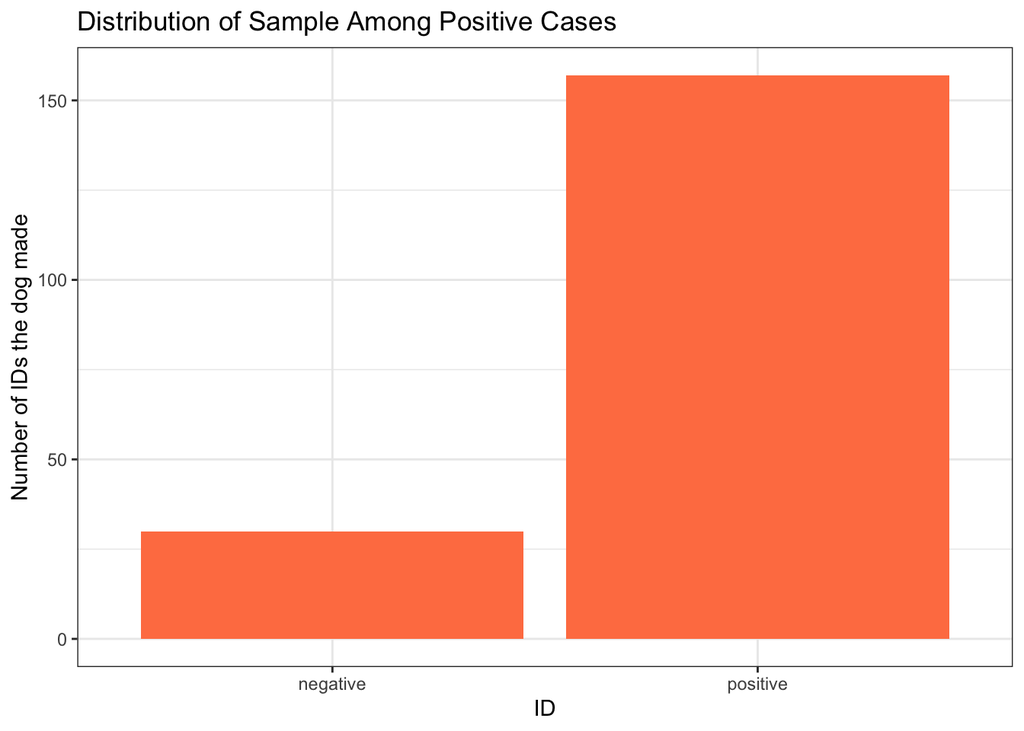

```r
ggplot(pos_cases) +
  geom_bar(aes(x = ID), fill = "coral") +
  labs(title = "Distribution of Sample Among Positive Cases",
       y = "Number of IDs the dog made") +
  theme_bw()
```

3. This was just one sample. What we’re really interested in is how well this dog would do in the long run. What is our parameter of interest? Write it out in words.

**Answer:** The population proportion of positive cases that the dog correctly identifies

4. Generate a bootstrap distribution of 1,000 sample proportions. Create a histogram of your 1,000 sample proportions from this distribution. Since we’re going to be using randomization, let’s set a seed here so that we can reproduce our results in the future. I’ve gotten you started with the code below. When you’re ready to run the code, change `eval = FALSE` to `eval = TRUE`.

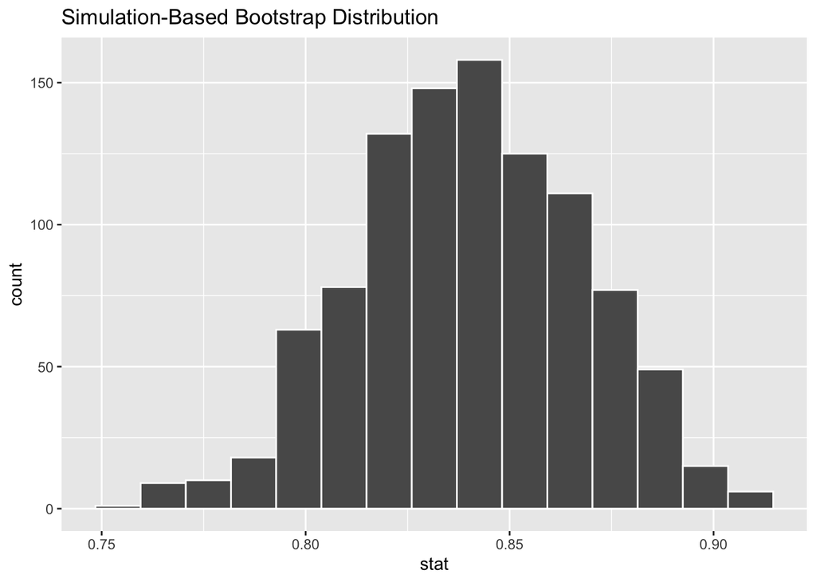

```r
set.seed(20240405)
pos_boot <- pos_cases |>
  specify(formula = ID ~ NULL, success = "positive") |>
  generate(reps = 1000, type = "bootstrap") |>
  calculate(stat = "prop")
visualize(pos_boot)
```

5. Create a 95% confidence interval using either the standard error method or the percentile method. Write the interval below.

```r
pos_boot |>
  get_ci(type = "se",
         point_estimate = pos_xbar,
         level = 0.95)
```

```
## # A tibble: 1 × 2
##   lower_ci upper_ci
##      <dbl>    <dbl>
## 1    0.787    0.892
```

**95% CI:** (0.787, 0.892)

**Method used:** Standard error

6. Provide a sentence interpreting your interval in context of this example.

**Interpretation (option 1):** We are 95% confident that the population proportion of positive samples that the dog can correctly identify is between 0.787 and 0.892.

**Interpretation (option 2):** We are 95% confident that the dog can correctly identify between 78.7% and 89.2% of positive samples.

7. Suppose we wanted a narrower interval than the one we got. How could we achieve that?

**Answer:** The easiest way would be to decrease our confidence level (e.g. to 90%). The researchers could also gather more data from the dog to get a narrower interval.

8. Calculate a 95% confidence interval using the appropriate theory-based method function. Is it reasonable to use a theory-based method in this situation? Why or why not?

```r
prop.test(x = 157,
          n = 157 + 30,
          conf.level = 0.95)
```

```
##
##  1-sample proportions test with continuity correction
##
## data:  157 out of 157 + 30, null probability 0.5
## X-squared = 84.898, df = 1, p-value < 2.2e-16
## alternative hypothesis: true p is not equal to 0.5
## 95 percent confidence interval:
##  0.7772625 0.8875293
## sample estimates:
##         p
## 0.8395722
```

**95% CI:** (0.777, 0.888)

**Explanation:** We have well over 5 successes and failures, so a theory-based method should be reasonable (assuming the data is a random sample, but if it is not we also would not want to use our bootstrap method).

# Part 2 - How much college students sleep

Below, I load in a dataset from a study related to sleep and grades of college students. For now, let’s focus just on the amount of sleep students get. The code below will read the data into R, convert sleep time from minutes to hours, and subset the data to focus on only one of the five studies.

```r
sleep <- read.csv("https://raw.githubusercontent.com/nbussberg/STS2300-Fall2025/refs/heads/main/Data/sleep_gpa_studies.csv") |>
  mutate(sleep_hrs = TotalSleepTime / 60) |>
  filter(study == 4) |>
  select(sleep_hrs)
```

9. Make a graph exploring the distribution of the `sleep_hrs` variable. Describe what the graph shows about this data.

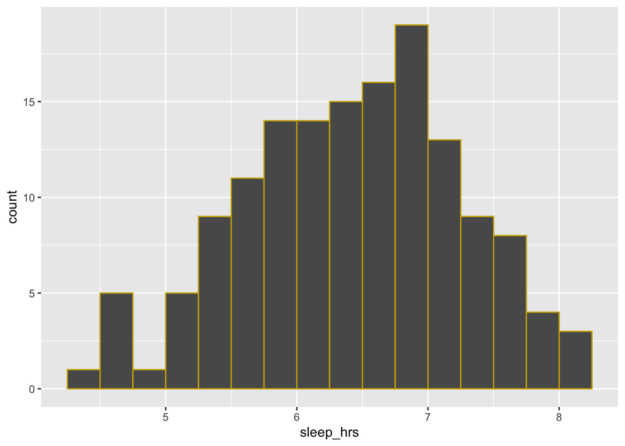

```r
ggplot(sleep, aes(x = sleep_hrs)) +
  geom_histogram(binwidth = 0.25,
                 color = "gold3",
                 boundary = 6)
```

10. Calculate the sample mean hours of sleep in this study.

```r
sleep_xbar <- mean(sleep$sleep_hrs)
```

**Estimate:** $\bar{x} = 6.42$

11. Create a bootstrap distribution of 1,000 sample means to get a better sense as to how much our estimate would vary from sample to sample. Make a histogram of your bootstrap sample means. (Note: The `set.seed()` line will ensure we get the same result each time we knit our document. You should replace the number with a number of your choosing.)

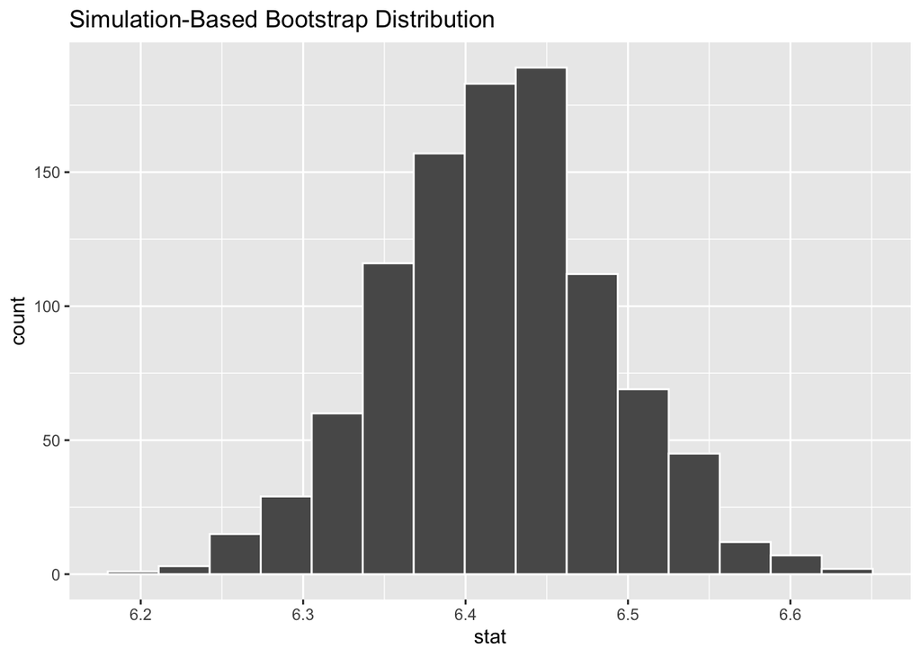

```r
set.seed(3194)
sleep_boot <- sleep |>
  specify(sleep_hrs ~ NULL) |>
  generate(reps = 1000, type = "bootstrap") |>
  calculate(stat = "mean")
visualize(sleep_boot)
```

12. Describe the graph you created in the previous question (e.g. shape, center, spread).

**Histogram description:** The graph is bell-shaped and contains sample means between roughly 6.2 and 6.6. It is centered just about 6.4 (on our sample mean from our actual sample).

13. Create a 90% confidence interval using your bootstrap distribution and write it below. Use whichever method (SE or percentile) you did not use in Part 1.

```r
sleep_boot |>
  get_ci(type = "percentile",
         level = 0.9)
```

```
## # A tibble: 1 × 2
##   lower_ci upper_ci
##      <dbl>    <dbl>
## 1     6.31     6.54
```

**90% CI:** (6.31, 6.54)

**Method used:** Percentile

14. Provide an interpretation of your interval in context of this example. (Note: Remember that we are studying college students.)

**Interpretation:** We are 90% confident that the population mean average nightly sleep time for college students is between 6.31 and 6.54 hours.

15. Calculate a 90% confidence interval using the appropriate theory-based method function. Is it reasonable to use a theory-based method in this situation? Why or why not?

```r
t.test(x = sleep$sleep_hrs, conf.level = 0.9)
```

```
##
##  One Sample t-test
##
## data:  sleep$sleep_hrs
## t = 93.637, df = 146, p-value < 2.2e-16
## alternative hypothesis: true mean is not equal to 0
## 90 percent confidence interval:
##  6.305654 6.532615
## sample estimates:
## mean of x
##  6.419134
```

**Explanation:** It is likely reasonable to use a theory-based interval here. The sample was roughly bell-shaped (suggesting the population also may be). Even if the population isn’t bell-shaped, we have a sample size of well over 30. (As before, we would also need this to be a random sample to make any kind of confidence interval.)